# Machine Learning Parameters Experiment

## Background

Internet of things or IoT for short, is transforming Industrial factories and how they collect data. IoT is the concept of having sensors collect information and upload it to the cloud, where it then can be used for analysis and decision making.

Many manufacturers are transitioning to using IoT practices and data collection to make further informed decisions. One of these practices includes using this machine data to predict possible failures or down times, which can hinder production and be rather costly.

A machine learning model can help to predict future down times, and allow for scheduled preventative maintenance saving money and time.

For this scenario we have already built a machine learning model to predict whether or not a certain machine will be down. We want to evaluate and adjust our parameters to increase performance.

For further curiosity on the individual machine learning project, please [click here to view my executive summary.](https://docs.google.com/document/d/1U19kaZ5FssiQMc-YQeUkA22OnNddkbsb6_TNfd2W3dk/edit?usp=sharing)

## Introduction

Within machine learning I have been told that feature building is one of the most important aspects that drives model performance, and that adjusting model parameters is the cherry on top.

The machine learning model we will be experimenting on is a **RandomForestClassifier()**, which takes into account certain columns in your data frame to classify each row as one of a few options. In this scenario we will be predicting whether or not a machine will be down during that day.

There are a few aspects that we will be testing. I have made a few complex features that are intended to pickup on patterns within the model. We are going to either include these features or exclude them for our **Between Block Factor**.

We will be using multiple machine learning models with different test train split seeds, randomly assigned. When working with a model the seed can often vary the performance of your model and how you determine how well you did, this will be our **Blocks**.

Our **Within-Block Factor** will be a model parameter that we want to test. We will be using the **max_depth** parameter to determine whether or not the value matters. We will have random values chosen for this, ranging from 3 to 9, we will have 3 factor levels.

For our response variable we are using the **F1- Score**, as it is a harmonic mean of Precision and Recall, giving us a better representation as opposed to just one metric.

Since our F1-score is calculate by using precision and recall here’s a recap:

- **Precision**: Measures the proportion of predicted positive cases that were actually positive

$$\text{Precision} = {\text{True Positives}\over{\text{True Positives} + \text{False Positives}}}$$

- **Recall**: Measures the proportion of actual positive values that were predicted as such.

$$\text{Recall} = {\text{True Positives}\over{\text{True Positives} + \text{False Negatives}}}$$

- **F1 - Score Formula**

$$\text{F1-Score} = 2*{{\text{Precision}*\text{Recall}}\over{\text{Precision}+\text{Recall}}}$$

The F1 score demonstrates a balance between Precision and Recall. The values will range from 0 to 1, where closer to 1 demonstrating better performance of the model.

Factor Structure:

- **Between Block Factor**: Added features, or no added features
- **Blocks**: Different random seeds set
- **Within-Block Factor**: Random Levels of the **max_depth** parameter
- **Response Variable**: F1-Score

## Model

$$y_{ijk} = \mu + \alpha_{i} + \beta_{ij} + \gamma_k + (\alpha\gamma)_{ik} + \epsilon_{ijk}$$

## Hypothesis

A hypothesis for the main effect of **feature/no feature**:

$$H_0: \alpha_{\text{Added Features}} = \alpha_{\text{No Added Features}} = 0$$

$$H_a: \alpha_i \neq 0 \text{ for some }i$$

A hypothesis for the main effect of **max_depth**:

$$H_0: \gamma_{\text{Depth: 3}} = \gamma_{\text{Depth: 5}} = \gamma_{\text{Depth: 9}} = 0$$

$$H_a: \gamma_k \neq 0 \text{ for some }k$$

A hypothesis for the interaction of **feature/no feature** and **max_depth**:

$$H_0: (\alpha\gamma)_{ik} = 0 \text{ for all }ik$$

$$H_a: (\alpha\gamma)_{ik} \neq 0 \text{ for some }ik$$

## Methodology

For this study I have already created a basic machine learning model in python. This model looks at different aspects of the machine such as `Hydraulic_Pressure`, `Hydraulic_Oil_Temp`, `Torque(Nm)`, and etc. just to name a few. It looks at this sensor data and predicts whether or not the machine will be down during that day.

I am going to run a for loop that randomly decides whether to run the **RandomForestClassifier()** on the data frame that has added features or not, as well as randomly decide a “random seed”. As these conditions will be run with each value in the set of **max_depth** values.

I will implement a for loop that performs the following actions for each specified `max_depth` value:

- Random Decision to Add Features: The loop will randomly decide whether to run the `RandomForestClassifier()` on the data frame with added features or without them
- Random Seed Selection: A random seed will also be chosen in each iteration to ensure variability in this process

These randomized conditions will be executed for each value of `max_depth` set $[3,5,9]$. The for loop is set to replicate this process 15 time depth in the set as to get a good representation of each depth.

## Data

```r
# load in the data csv file and any other packages needed
# or any transformations
library(tidyverse)
library(readr)
library(car)
library(pander)

ml<- read_csv("ml_anova.csv")

ml <- ml %>% mutate(
  Feature = case_when(
    Feature == 0 ~ "Without Added Features",
    Feature == 1 ~ "With Added Features"
  )
)
```

## Summary Stats

By Feature:

```r
partic_stats <- ml %>%
  group_by(Feature) %>%
  summarise(
    min = min(F1_score),
    Q1 = quantile(F1_score, 0.25),
    median = median(F1_score),
    mean = mean(F1_score),
    Q3 = quantile(F1_score, 0.75),
    max = max(F1_score),
    sd = sd(F1_score),
    n = n()
  )
pander(partic_stats)
```

Table continues below

| Feature | min | Q1 | median | mean | Q3 | max |
| --- | --- | --- | --- | --- | --- | --- |
| With Added Features | 0.9817 | 0.9894 | 0.996 | 0.9929 | 0.9975 | 0.9981 |
| Without Added Features | 0.9261 | 0.9335 | 0.9658 | 0.9606 | 0.9816 | 0.9878 |

| sd | n |
| --- | --- |
| 0.005241 | 22 |
| 0.02319 | 23 |

By Depth:

```r
partic_stats <- ml %>%
  group_by(Depth) %>%
  summarise(
    min = min(F1_score),
    Q1 = quantile(F1_score, 0.25),
    median = median(F1_score),
    mean = mean(F1_score),
    Q3 = quantile(F1_score, 0.75),
    max = max(F1_score),
    sd = sd(F1_score),
    n = n()
  )
pander(partic_stats)
```

| Depth | min | Q1 | median | mean | Q3 | max | sd | n |
| --- | --- | --- | --- | --- | --- | --- | --- | --- |
| 3 | 0.9261 | 0.9283 | 0.9602 | 0.9571 | 0.985 | 0.9919 | 0.02823 | 15 |
| 5 | 0.9593 | 0.9665 | 0.9918 | 0.983 | 0.996 | 0.9979 | 0.01532 | 15 |
| 9 | 0.9711 | 0.985 | 0.9878 | 0.9891 | 0.998 | 0.9981 | 0.008669 | 15 |

By Interaction:

```r
partic_stats <- ml %>%
  group_by(Feature, Depth) %>%
  summarise(
    min = min(F1_score),
    Q1 = quantile(F1_score, 0.25),
    median = median(F1_score),
    mean = mean(F1_score),
    Q3 = quantile(F1_score, 0.75),
    max = max(F1_score),
    sd = sd(F1_score),
    n = n()
  )
pander(partic_stats)
```

Table continues below

| Feature | Depth | min | Q1 | median | mean | Q3 |
| --- | --- | --- | --- | --- | --- | --- |
| With Added Features | 3 | 0.9817 | 0.9845 | 0.9864 | 0.9866 | 0.9888 |
| With Added Features | 5 | 0.9866 | 0.9921 | 0.996 | 0.9943 | 0.9961 |
| With Added Features | 9 | 0.9894 | 0.9971 | 0.998 | 0.9966 | 0.9981 |
| Without Added Features | 3 | 0.9261 | 0.9271 | 0.9289 | 0.9375 | 0.9364 |
| Without Added Features | 5 | 0.9593 | 0.9609 | 0.9645 | 0.9659 | 0.9668 |
| Without Added Features | 9 | 0.9711 | 0.9811 | 0.985 | 0.9827 | 0.9869 |

| max | sd | n |
| --- | --- | --- |
| 0.9919 | 0.003675 | 6 |
| 0.9979 | 0.003528 | 9 |
| 0.9981 | 0.003223 | 7 |
| 0.9735 | 0.01727 | 9 |
| 0.9802 | 0.007613 | 6 |
| 0.9878 | 0.006199 | 8 |

## Exploration

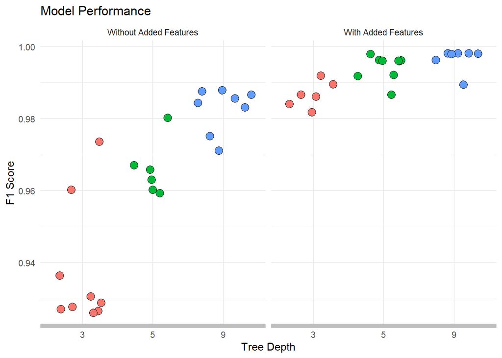

```r
ggplot(ml, aes(x=as.factor(Depth), y=F1_score, fill=as.factor(Depth))) +
  geom_jitter(pch=21,size=3.5)+
  facet_grid(~factor(Feature, levels=c("Without Added Features", "With Added Features")))+
  theme_minimal() +
  labs(
    title="Model Performance",
    x="Tree Depth",
    y="F1 Score"
  ) +
  theme(
    legend.position = "none",
    axis.line.x = element_line(color="grey", size=2)
  )
```

Looking at the graph above we can see an interesting pattern. Both of our Feature facets seem to increase in F1 score as we get a further increase in tree depth. In the *Without Added Features* it appears that Tree depth has a larger effect on the F1-score than it does in the *Added Features* facet.

One of my initial concerns with having a deep tree max depth has to do with over fitting. When we set too deep of a `max_depth` parameter, it increases the odds of over fitting the model, where it may do well on the data given, but not as well on new data.

## Analysis of Variance

```r
ml <- ml %>%
  mutate(
    Seed = factor(Seed),
    Depth = factor(Depth)
  )


mlaov <- aov((F1_score) ~ Feature + Seed + Depth + Feature:(Depth),
             contrasts = list(Feature = contr.sum, Seed = contr.sum, Depth = contr.sum),
             data=ml)

pander(car::Anova(mlaov, type = 3, contrasts = list(Feature = contr.sum, Seed = contr.sum, Depth = contr.sum), singular.ok=TRUE)
)
```

Anova Table (Type III tests)

|  | Sum Sq | Df | F values | Pr(>F) |
| --- | --- | --- | --- | --- |
| **Feature** | 0.002625 | 1 | 694.8 | 0.0001198 |
| **Seed** | 0.003164 | 36 | 23.26 | 0.01206 |
| **Depth** | 2.322e-05 | 1 | 6.145 | 0.08936 |
| **Feature:Depth** | 0.0001386 | 1 | 36.68 | 0.009032 |
| **Residuals** | 1.134e-05 | 3 | NA | NA |

I decided to use a Type III sum of squares as our data is imbalanced within our **Between Block**.

We can see that we have a significant interaction so we will ignore the other factors, and move on to creating an interaction chart, after checking our assumptions.

## Assumptions

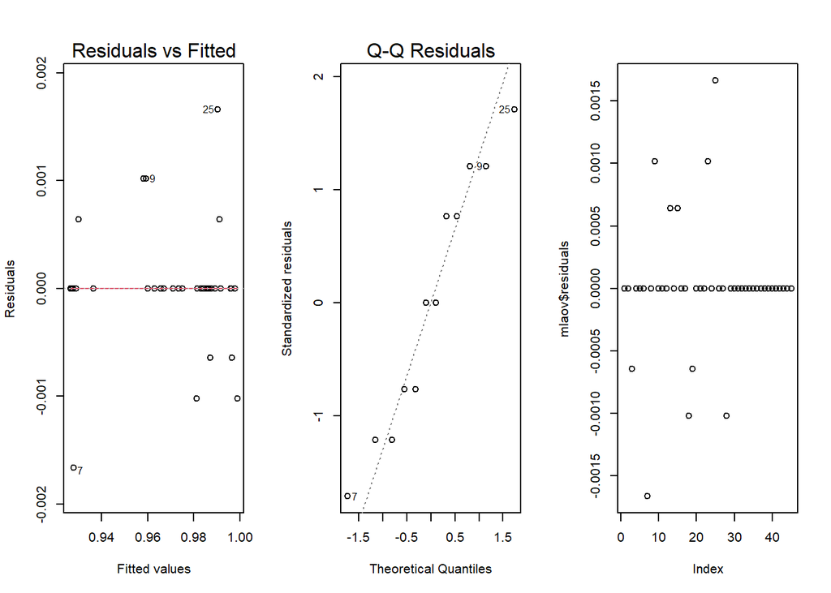

```r
par(mfrow=c(1,3))
plot(mlaov, which=1)
#car::qqPlot(mlaov$residuals)
plot(mlaov, which=2)
plot(mlaov$residuals)
```

**Constant Variance** : Looking at our Residuals vs. Fitted graph we don’t really see much of a wedge shape or a megaphone, there’s is oddly a great deal of points that sit exactly at zero on the y-axis, we have determined that there is numerous values sitting at the same value within our data.

**Normality** : We want our residuals to follow our line in order to assume normality, as our residuals apear to waive on the line, it still follows the line well. Letting us assume the assumption of normality is met.

**Ordered plot** : Our order plot really looks fine, except for the many values sitting at zero as well as the points in the other graphs following this pattern.

## Further Analysis

Our interaction in our anova model had a significant effect, so we are going straight into interpreting our interaction plot.

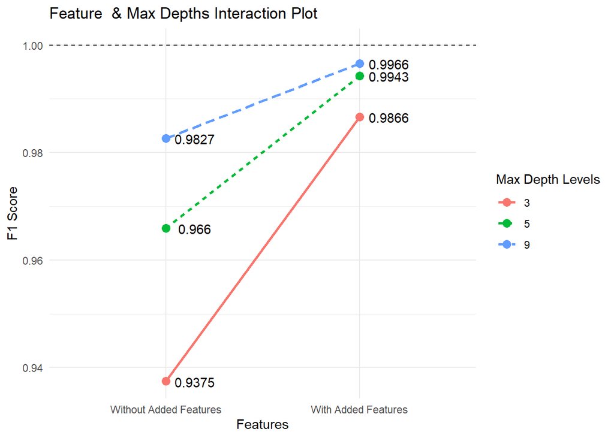

```r
library(emmeans)
#ml_means = emmeans(mlaov, c("Feature", "Depth"))
#ml_means

# pairwise-contrast, interaction plot is more important than the contrast table that would be created
# having problems with contrasts....
ggplot(ml,
       aes(x=Feature, color=Depth, group=Depth, linetype=Depth, y=F1_score)) +
  stat_summary(fun=mean, geom="line", size=1) +
  stat_summary(fun=mean, geom="point", size=3) +
  labs(x="Features",
       y="F1 Score",
       title="Feature  & Max Depths Interaction Plot",
       color="Max Depth Levels",
       linetype="Max Depth Levels") +
  theme_minimal()+
  scale_x_discrete(limits = c("Without Added Features", "With Added Features")) +
  geom_hline(yintercept = 1, linetype=2)+
  stat_summary(
    fun = mean,  # Add text labels for the means
    geom = "text",
    aes(label = round(..y.., 4)),  # Use `..y..` to access the computed mean
    position = position_nudge(x = 0.15, y=-0.0001),
    color = "black"
  )
```

A few concepts to preface this chart: when working with machine learning models you are always trying and attempting to improve you model, getting our performance metrics closer and closer to 1 but will never quite getting there, without over fitting. We can see a clear difference, being F1 Scores that have the added features, as the range of points get tighter and increase in value.

Demonstrating initial values of $\text{Max Depth: 5}=0.966$ & $\text{Max Depth: 9}=0.9827$ with a difference of $0.0167$, compared to with added features $\text{Max Depth: 5}=0.9943$ & $\text{Max Depth: 9}=0.9966$ with a difference of $0.0023$. For any other context this contrast would appear inconsequential, but for our situation where we would like to use a lower max depth value in order to prevent over fitting, it allows us to confidently choose our max depth level of 5 to prevent over fitting and return a similar F1 score.

## Conclusion

We were able to determine that typically having larger max depth value generally increases our model performance, though having a too large max depth value can cause over fitting. We decided for this particular project that we are going to use a max depth value of 5, as the difference between our max depth levels of 5 and 9 within the added features tick is relatively small and lower values will protect us more from overfitting.